# Managing for ecological surprises in metapopulations

Supplemental materials

Kyle Logan Wilson$^1$, Colin Bailey$^1$, William Atlas$^1$, and Doug Braun$^2$ $^1$Earth to Ocean Research Group, Simon Fraser University $^2$Fisheries & Oceans Canada

02 July 2019

## Metapopulation model

### Local & metapopulation dynamics

Our metapopulation is defined by a set of local populations $N_p$ with time-dynamics that follows birth (i.e., recruitment *R*), immigration, death, and emigration (BIDE) processes:

$N_{it}= R_{it}\epsilon_{it}+I_{it}-D_{it}-E_{it}$

where $N_{it+1}$ is the number of adults in patch *i* at time *t*, $R_{it}$ is number of recruits, $I_{it}$ is number of recruits immigrating into patch *i* from any other patch, $D_{it}$ is number of recruits that die due to disturbance regime, $E_{it}$ is the number of recruits emigrating from patch *i* into any other patch, and $\epsilon_{it}$ is stochasticity in recruitment.

Resoure monitoring often occurs at the scale of the metapopulation, hence we define metapopulation adults as:

${MN}_t = \sum_{i=1}^{N_p} N_{it}$

with metapopulation recruits:

$MR_t = \sum_{i=1}^{N_p} R_{it}$

Local patch recruitment at time *t* depended on adult densities at *t-1* and followed a reparameterized Beverton-Holt function:

$R_{it}=\cfrac{\alpha_iN_{it-1}}{1+\cfrac{\alpha_i-1}{\beta_i}N_{it-1}}$

where $\alpha_i$ is the recruitment compensation ratio and $\beta_i$ is local patch carrying capacity.

For example, in a two patch model that varies $\alpha_i$ and $\beta_i$ parameters such that

```r
alpha <- c(2, 4)
beta <- c(100, 200)
```

Management often monitors metapopulation resources as the aggregate of all local populations. In this way, recruitment compensation from local patches $\alpha_i$ gets averaged across the metapopulation leading to a mean compensation $\bar{\alpha}$ of 3. Likewise, the total carrying capacity of the metapopulation $\bar{\beta}$ becomes the summation of local patch carrying capacities $\sum\beta_i$, which is 300. This scale of monitoring generates the following local patch and metapopulation dynamics:

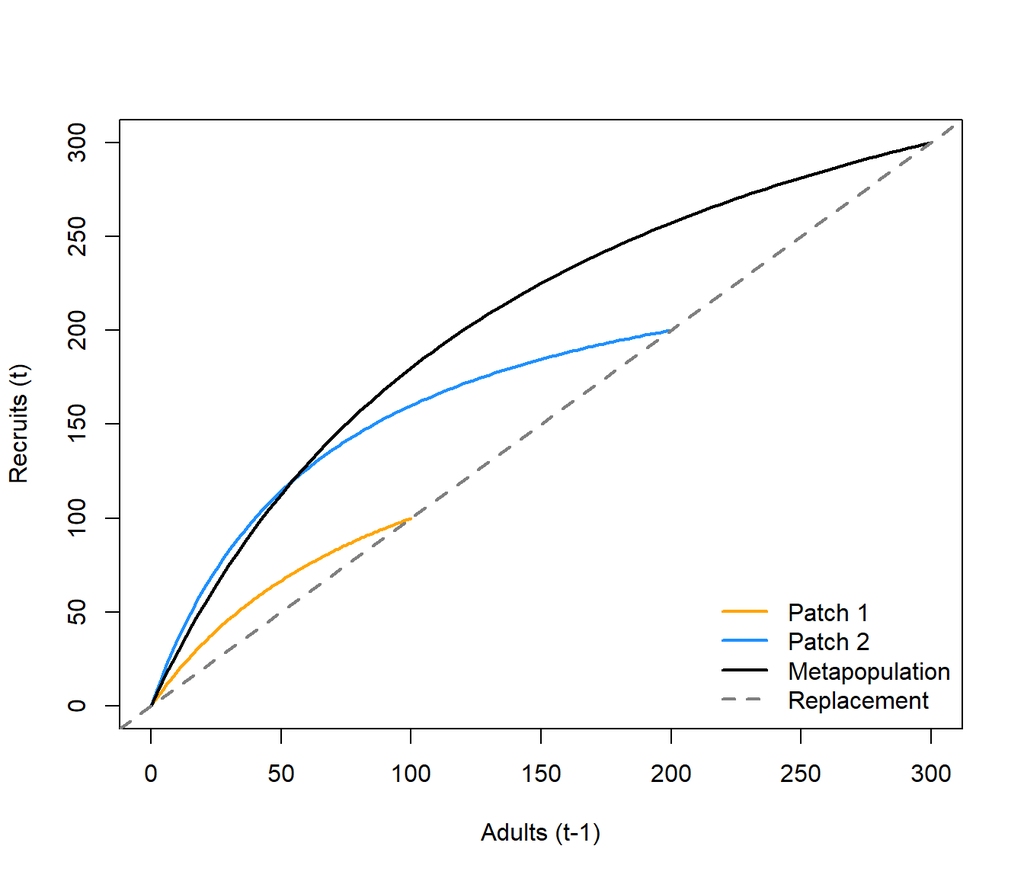

Metapopulation and local patch recruitment dynamics.

### Creating the spatial networks

The next aspect to our metapopulation model is connecting the set of patches to one another. We need to specify the number of patches, their arrangements (i.e., connections), and how far apart they are from one another. We followed some classic metapopulation and source-sink arrangements to create four networks that generalize across a few real-world topologies: a linear habitat network (e.g., coastline), a dendritic or branching network (e.g., coastal rivers), a star network (e.g., mountain & valley), and a complex network (e.g., terrestrial plants).

To make networks comparable, each spatial network type needs the same leading parameters (e.g., $N_p$ and $\bar{d}$) . In this case for number of patches, we set $N_p$ to `16` and $\bar{d}$ to `1` unit (distance units are arbitrary). We used the `igraph` package and some custom code to arrange our spatial networks as the following:

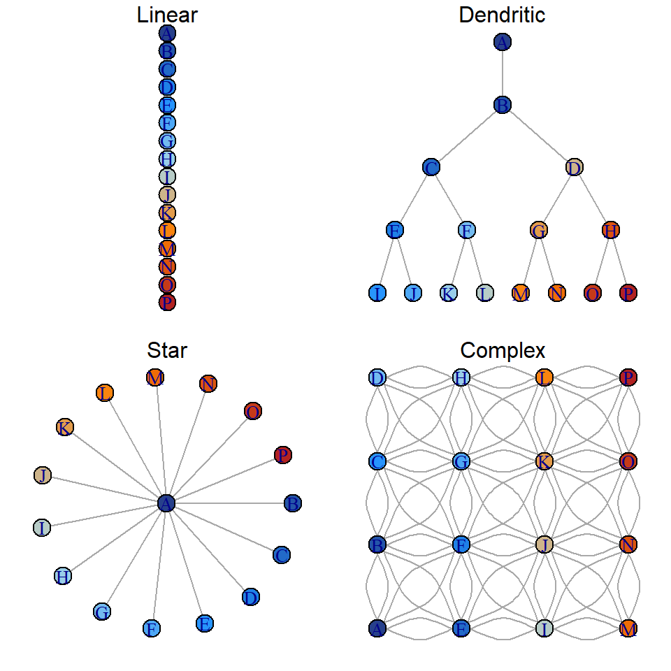

Four spatial network topologies.

Note that distances between neighbor patches in the above networks are equal.

An example dispersal matrix for the complex network:

```
##   A B E F C G D H I J K L M N O P
## A 0 1 1 1 2 2 3 3 2 2 2 3 3 3 3 3
## B 1 0 1 1 1 1 2 2 2 2 2 2 3 3 3 3
## E 1 1 0 1 2 2 3 3 1 1 2 3 2 2 2 3
## F 1 1 1 0 1 1 2 2 1 1 1 2 2 2 2 2
## C 2 1 2 1 0 1 1 1 2 2 2 2 3 3 3 3
## G 2 1 2 1 1 0 1 1 2 1 1 1 2 2 2 2
## D 3 2 3 2 1 1 0 1 3 2 2 2 3 3 3 3
## H 3 2 3 2 1 1 1 0 3 2 1 1 3 2 2 2
## I 2 2 1 1 2 2 3 3 0 1 2 3 1 1 2 3
## J 2 2 1 1 2 1 2 2 1 0 1 2 1 1 1 2
## K 2 2 2 1 2 1 2 1 2 1 0 1 2 1 1 1
## L 3 2 3 2 2 1 2 1 3 2 1 0 3 2 1 1
## M 3 3 2 2 3 2 3 3 1 1 2 3 0 1 2 3
## N 3 3 2 2 3 2 3 2 1 1 1 2 1 0 1 2
## O 3 3 2 2 3 2 3 2 2 1 1 1 2 1 0 1
## P 3 3 3 2 3 2 3 2 3 2 1 1 3 2 1 0
```

### Dispersal

Dispersal from patch *i* into patch *j* depends on constant dispersal rate $\omega$ (defined as the proportion of total local recruits that will disperse) and an exponential distance-decay function between *i* and *j* with distance cost to dispersal $m$ following:

$E_{ij(t)}=\omega R_{it}p_{ij}$

where $E_{ij}$ is the total dispersing animals from patch *i* into patch *j* resulting from dispersal rate $\omega$, total number of local recruits $R_{it}$, and probability of dispersal between patches $p_{ij}$:

$p_{ij}=\dfrac{e^{-md_{ij}}}{\sum\limits_{\substack{j=1 \\ j\neq i}}^{N_p} e^{-md_{ij}}}$

where $d_{ij}$ is the pairwise distance between patches, $m$ is the distance cost to dispersal. The summation term in the denominator normalizes the probability of moving to any patch to between 0 and 1 with the constraint that dispersers cannot move back into their home patch (i.e., $j\neq i$. With $\bar{d}= 1$, $m=0.5$, $\omega=0.1$, $R_{it}=100$ in a linear network:

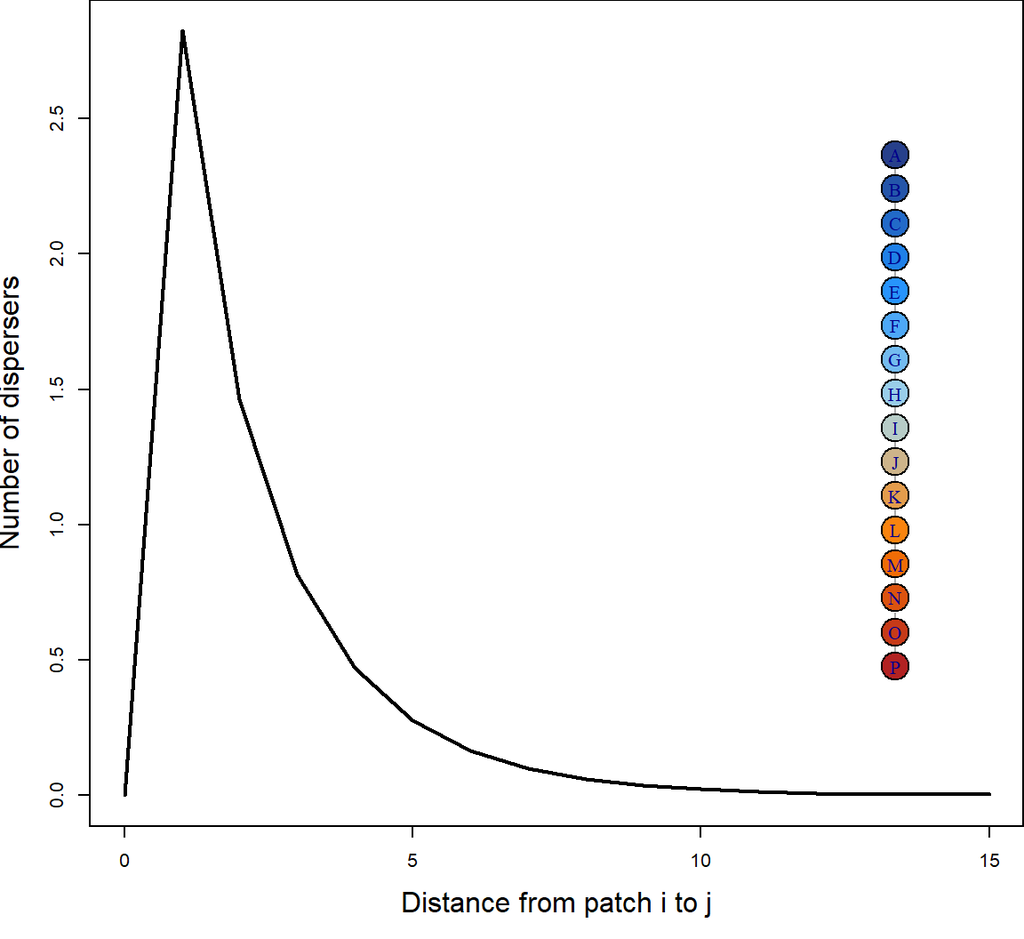

Example dispersal patterns across linear network.

### Disturbance regimes

In all scenarios, disturbance was applied after `50` years of equilibrating the metapopulaton at pristine conditions. At year `51`, we applied the disturbance regime (the regime varied from *uniform*, *localized, random*, and *localized, extirpation* - see *Scenarios* below). Disturbance immediately removes a set proportion of the metapopulation adults at that time (i.e., `0.9` of $MN_{t=51}$). Once applied, the metapopulation was no longer disturbed and spatio-temporal recovery dynamics emerged naturally from these new conditions.

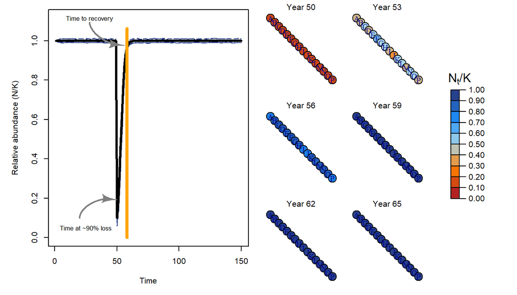

Recovery regime of metapopulation with linear topology through time (left) and space (right).

### Recruitment stochasticity

Our model allowed for stochastic recruitment that followed a lognormal distribution with average variation in recruitment of $\sigma_R$. In cases of stochastic recruitment, the expected recruitment:

$R_{it}=\cfrac{\alpha_iN_{it-1}}{1+\cfrac{\alpha_i-1}{\beta_i}N_{it-1}}$

becomes:

$R_{it}=\cfrac{\alpha_iN_{it-1}}{1+\cfrac{\alpha_i-1}{\beta_i}N_{it-1}}e^{(\epsilon_{it}-\cfrac{ln(\sigma_{R}^2+1)}{2})}$

where lognormal deviates for each patch *i* at time *t* are drawn from a multivariate normal distribution (*MVN*) If $\sigma_R$ is low, then metapopulation dynamics approach the deterministic case. In some scenarios, we evaluate the role of spatially and/or temporally correlated deviates across the metapopulations to model potential common drivers affecting metapopulation dynamics (e.g., Moran effects). Expected recruitment deviates followed a first-order autoregression model such that:

$\epsilon_{it}=\rho_T\epsilon_{t-1}+MVN(\mu=0,\Sigma=\sigma_R(1-\rho_T^2)e^{(-\rho_SD_{ij})})$

where $\rho_T$ is temporal correlation (bounded $0-1$) $\rho_S$ is rate of distance-decay in spatial correlation (bounded $0-\infty$ with higher values leading to independent patches). If $rho_T$ is 0 and $rho_S$ is high, then annual recruitment deviates are independent. We illustrate the effects of four kinds of recruitment deviates below using the same random number generator seed:

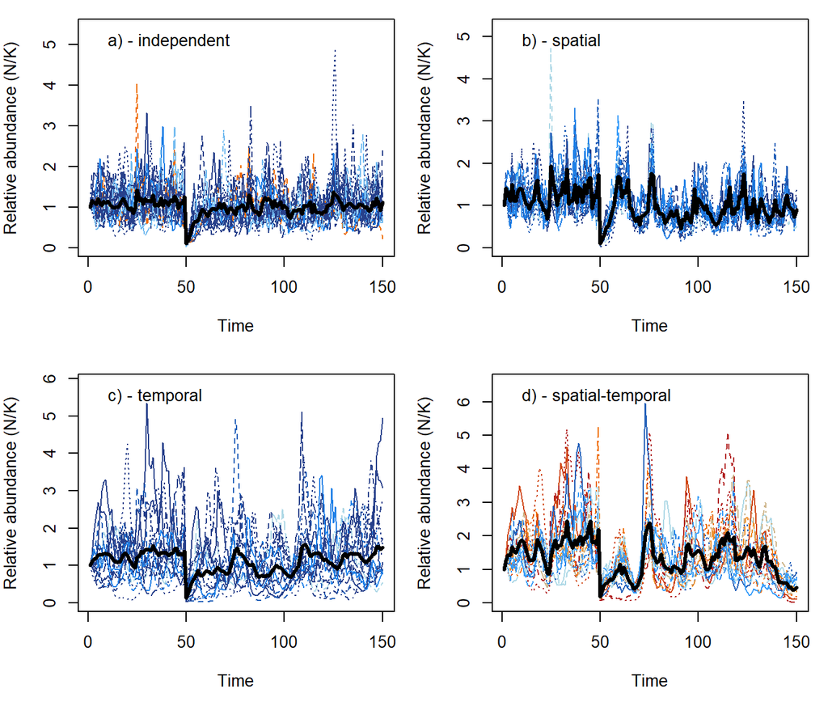

Metapopulation dynamics with independent (a), spatially correlated (b), temporally correlated (c), and spatio-temporally correlated (d) recruitment deviates.

## Post-disturbance outcomes

We measured the following post-disturbance outcomes that measure various conservation and recovery processes.

1. Recovered (a) & recovery rate (b) after disturbance - (a) the number of simulations where metapopulation abundance averaged `1.0` of the average pre-disturbance abundance for `5` consecutive years post-disturbance, and (b) the number of years it took to get there.
2. Extinction (a) & extinction rate (b) - (a) the number of simulations where metapopulation abundance was `<0.05` carrying capacity, and (b) the mean number of years it took to get there.
3. Patch occupancy - the mean number of patches with `>0.1` local carrying capacity.
4. Spatial variance - the variation in patch abundance across patches within a given window of time.
   1. Within 5 years post-disturbance
   2. Within 10 years post-disturbance
   3. Within 25 years post-disturbance
5. Number of populations defined as source, sink, pseudo-sink such that:
   1. Sources provide surplus recruits and net emigrants such that: $(R_{it}>N_{it})$ & $(E_{it}>I_{it})$
   2. Sinks consume recruits and net immigrants such that: $(R_{it} < N_{it})$ & $(E_{it} < I_{it})$
   3. Pseudo-sinks would provide surplus recruits in the absence of dispersal such that $(R_{it}>N_{it})$ but $(R_{it}+E_{it}) < (R_{it-1}+I_{it-1}-E_{it-1})$
6. Fit stock-recruitment model to aggregate of metapopulation to estimate:
   1. Recruitment compensaton ratio compared to true metapopulation average
   2. Metapopulation carrying capacities compared to true sum of carrying capacities across metapopulation
   3. Expected recruitment production to true recruitment production across all patches
   4. Expected maximum surplus production (we term *MSY*) to true maximum surplus production across all patches

### Monitoring & management at aggregate-scale

While true metapopulation dynamics are controlled by local patch dynamics and dispersal such that:

$N_{it}= R_{it}\epsilon_{it}+I_{it}-D_{it}-E_{it}$

$R_{it}=\cfrac{\alpha_iN_{it-1}}{1+\cfrac{\alpha_i-1}{\beta_i}N_{it-1}}$

${MN}_t = \sum_{i=1}^{N_p} N_{it}$

${MR}_t = \sum_{i=1}^{N_p} R_{it}$

natural resoure managers often monitors and manages at the scale of the metapopulation. Hence, management at this scale inherently defines the stock-recruitment dynamics of the aggregate complex of patches (i.e., metapopulation) as:

${MR}_{t}=\cfrac{\hat{\alpha_t}{MN}_{t-1}}{1+\cfrac{\hat{\alpha_t}-1}{\hat{\beta_t}}{MN}_{it-1}}$

where $\hat{\alpha_t}$ is the estimated compensation ratio averaged across the metapopulation at time *t* and $\hat{\beta_t}$ is the estimated carrying capacity of the entire metapopulation. Necessarily, these estimates emerge from monitoring data collected across all patches and are sensitive to the quality of the data and how local patches perform through time. For example, temporal shifts in productivity regimes may be masked if most of the data were sampled before the regime shift. To help surmount these issues, modern resource assessments use data weighting and penalties (i.e., priors) when fitting models to data.

In our assessment, we weighted recent years of sampling over more distant years such that:

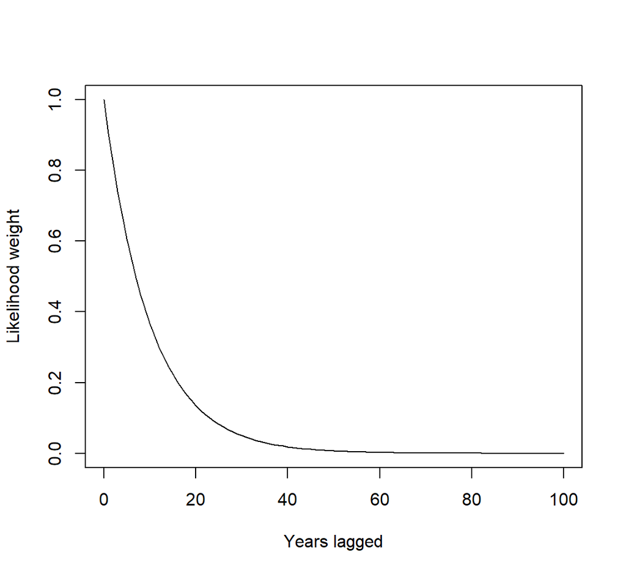

Likelihood weighting for samples collected over time from current year of sampling.

Furthermore, we used penalized normal likelihoods on both $\hat{\alpha_t}$ and $\hat{\beta_t}$ such that:

$\hat{\alpha_t} \sim N(\mu=\hat{\alpha_{t-1}},\sigma=3\hat{\alpha_{t-1}})$

and

$\hat{\beta_t} \sim N(\mu=\hat{\beta_{t-1}},\sigma=3\hat{\beta_{t-1}})$

where $\mu=\hat{\alpha_{t-1}}$ and $\mu=\hat{\beta_{t-1}}$ represents the best estimates from the previous assessment and the `3` in the $\sigma$ term represents a 300% coefficient of variation. We used these penalized likelihoods to fit the above aggregate stock-recruitment model with *lognormal* error to the metapopulation stock-recruit data collected at time *t*. We used the following function and fitted to the below $\theta$ parameters (termed `theta` in the function `optim()` using the `L-BFGS-B` optimizer with a lower bound on $\hat{\alpha}$ of `1.01` (i.e., constrained to be at least above replacement).

```r
SRfn <- function(theta) {
    a.hat <- theta[1]
    b.hat <- exp(theta[2])
    sd.hat <- exp(theta[3])
    rec.mean <- (a.hat * spawnRec$spawners)/(1 + ((a.hat - 1)/b.hat) * spawnRec$spawners)
    # negative log likelihood on recruitment parameters
    nll <- -1 * sum(dlnorm(spawnRec$recruits, meanlog = log(rec.mean), sdlog = sd.hat,
        log = TRUE) * spawnRec$weights, na.rm = TRUE)
    # penalized likelihood on estimated alpha
    penalty1 <- -dnorm(a.hat, alphaLstYr, 3 * alphaLstYr, log = TRUE)
    # penalized likelihood on estimated carrying capacity
    penalty2 <- -dnorm(b.hat, metaKLstYr, 3 * metaKLstYr, log = TRUE)
    jnll <- sum(c(nll, penalty1, penalty2), na.rm = TRUE)
    return(jnll)
}
```

This above function allows us to assess the bias in $\hat{\alpha_t}$, $\hat{\beta_t}$, and $\hat{MR_t}$ compared to true $\bar{\alpha}$, $\bar{\beta}$, and ${MR}_t$ across the metapopulation. This then allows us to see how much information management & monitoring programs are missing when they assess metapopulations at the aggregate (rather than local) scales.

### Finding maximum sustainable yield

Resource managers measure productivity with a variety of performance reference points. One of the most widely used metrics, commonly called *Maximum Sustainable Yield* in fisheries and other harvest literature ($MSY$), relates to the largest loss the population can sustain over an indefinite period of time while maximizing its ability to replenish itself. Under density-dependent growth, individuals’ growth, survival, and reproduction at low population densities are not constrained by limited resources, but overall production is low because there are few individuals. At high densities, limited resources increasingly constrain individual’s reproductive success until the population reaches carrying capacity, and overall production drops to zero because per-capita success is low. However, at some intermediate densities, both per-capita and overall production is high, and population growth is at its maximum point due to the large number of reproducing individuals. At this point, there is the maximum surplus of individuals produced above replacement that can help to withstand disturbance or harvest regimes and contribute to future recovery, either through increasing local patch densities or by emigrating neighboring patches providing “rescue effects”.

Under Beverton-Holt or Ricker density-dependent recuitment, however, there exists no analytical solution for calculating $MSY$. Therefore, we used numerical methods and a one dimensional root finder to iteratively search for the population mortality that maximized surplus production in the metapopulation. We term this mortality $F_{MSY}$ and can use this mortality value to calculate maximum surplus production $MSY$, the adult densities that produce $MSY$ (termed $N_{MSY}$), and the recruits that result from this (termed $R_{MSY}$).

```r
# uniroot numerical search

yieldRoot <- function(alpha, beta, Fcur, model) {
    Ucur <- 1 - exp(-Fcur)
    if (model == "Beverton-Holt") {
        # population model is R ~ (CR * S)/(1+(CR-1)/K * S): reparameterized
        # Beverton-Holt
        adults <- beta * exp(-Fcur)
        recruits <- (alpha * adults)/(1 + ((alpha - 1)/beta) * adults)
        yield <- recruits - adults
    }
    if (model == "Ricker") {
        # population model is R ~ CR * S * e(-log(CR)/K * S): reparameterized Ricker
        adults <- beta * exp(-Fcur)
        recruits <- alpha * adults * exp((-log(alpha)/beta) * adults)
        yield <- recruits - adults
    }
    return(list(recruits = recruits, adults = adults, yield = yield))
}

# Return approximate gradient for integral

fun_yield <- function(Fcur, alpha, beta, delta, model) {
    y1 <- yieldRoot(alpha = alpha, beta = beta, Fcur = Fcur - delta/2, model = model)$yield
    y2 <- yieldRoot(alpha = alpha, beta = beta, Fcur = Fcur + delta/2, model = model)$yield
    approx.gradient <- (y2 - y1)/delta
    return(approx.gradient)
}

# uniroot search for optimal yield and Fmsy
findMSY <- function(alpha, beta, Npatches, model) {
    F_msy <- NULL
    for (i in 1:Npatches) {
        a_p <- alpha[i]
        b_p <- beta[i]
        F_msy[i] <- uniroot(fun_yield, interval = c(0, 1), extendInt = "yes",
            alpha = a_p, beta = b_p, delta = 1e-04, model = model)$root
    }
    MSY <- sapply(1:Npatches, function(x) {
        yieldRoot(alpha = alpha[x], beta = beta[x], Fcur = F_msy[[x]][1], model = model)
    })
    return(list(F_msy = F_msy, MSY = MSY))
}
```

## Scenarios

### Example results

We demonstrate our metapopulation model with an example outcome for a linear network composed of `16` patches, a dispersal rate of `0.01` and a high enough dispersal cost such that individuals are only willing to move to their closest neighboring patches. This limits the strength of potential rescue effects. For this example, patches varied in their productivity and carrying capacity but will have deterministic population dynamics.

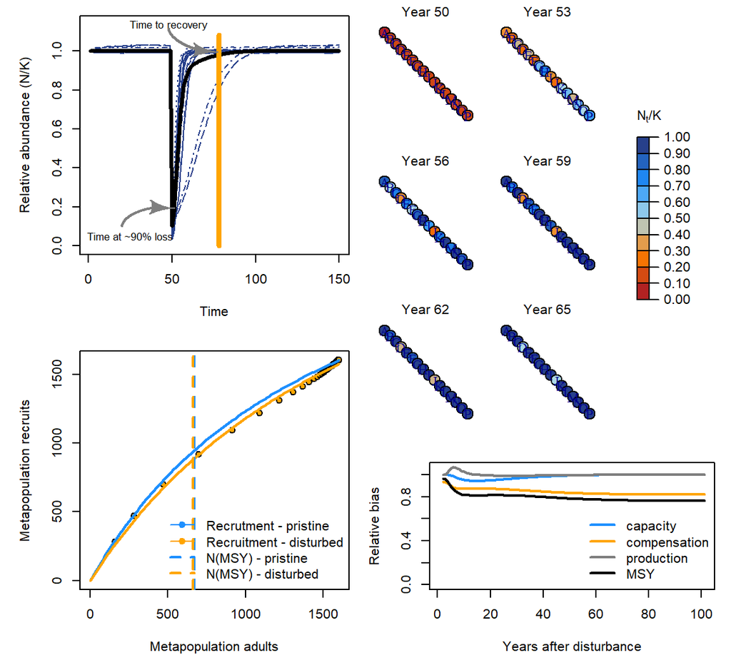

Spatial recovery regime of metapopulation with linear topology through time (top left) and space (top right). Recruitment dynamics before and 10 years after disturbance (bottom left). Relative bias in aggregate-scale estimates of carrying capacity, compensation ratio, and recruitment production in recovery phase (bottom right).

We can then contrast this with a different network shape, like a dendritic network.

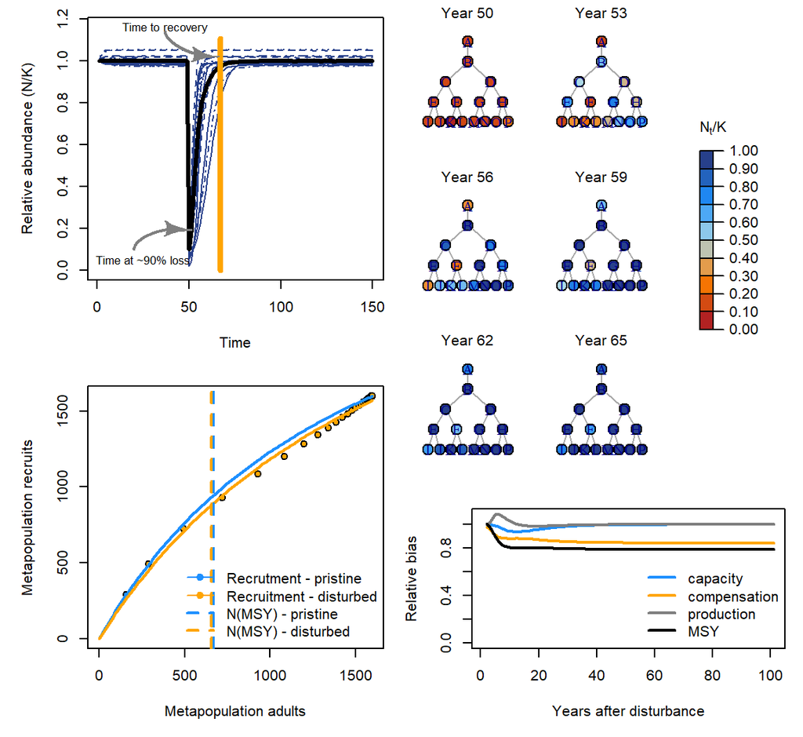

Spatial recovery regime of metapopulation with dendritic topology.

Now, let’s add some stochasticity to recruitment and see how this affects the recovery regime.

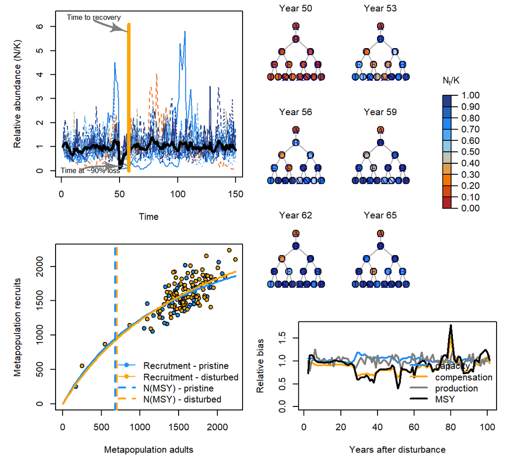

Spatial recovery regime of stochastic metapopulation.

Next, we can contrast with a disturbance regime where the disturbance is concentrated on local patches that can be completely extirpated (rather than the disturbance being applied proportionally across all patches e.g., a mixed-stock fishery).

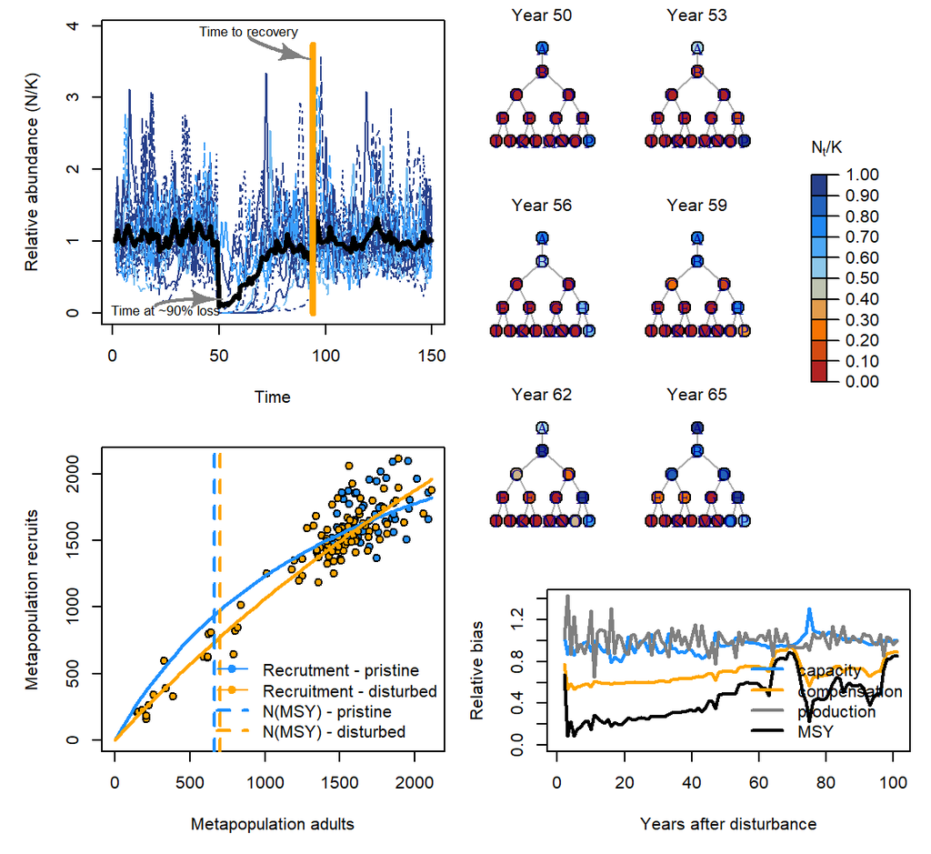

Spatial recovery regime of stochastic metapopulation.

## Simulation test & bootstrap

### General patterns

We now show some general patterns in how variable patch demographic rates, network structure, dispersal, disturbance, recruitment stochasticity, and spatio-temporal correlations variation effects metapopulation *recovery rates*, *maximum sustainable yield* (i.e., analagous to the maximum rate of loss the system can sustain), and *coefficient of variation* across patches.

First, lets show recovery rates for a scenario where (1) patches have the same local productivities, (2) patches have the same local carrying capacities, (3) recruitment is deterministic, (4) there is no spatial correlation in recruitment, and (5) there is no temporal correlations in recruitment.

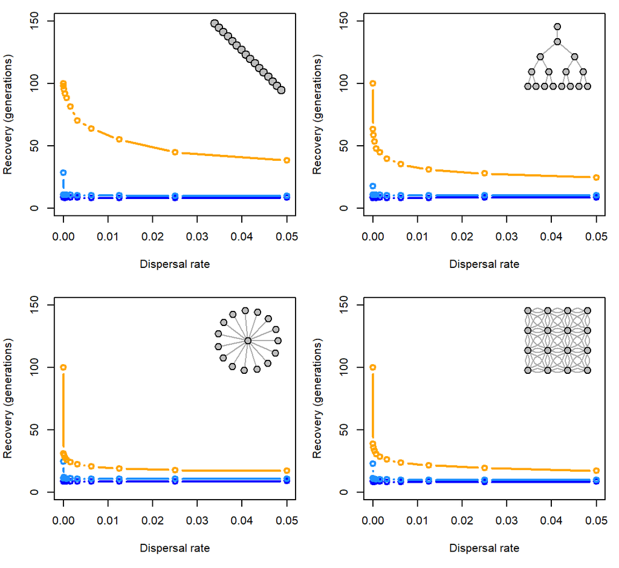

Recovery rates along dispersal, disturbance (blue - uniform; light blue - localized, random; orange - localized, extirpation), and network gradients without stochasticity.

Now, lets show recovery rates for the same scenario with deterministic recruitment but allowing for patches to vary in productivity and carrying capacity. In addition to the same three main effects of dispersal, network, and disturbance noted above, we also see variable patch productivities substantially slows recovery times across all scenarios.

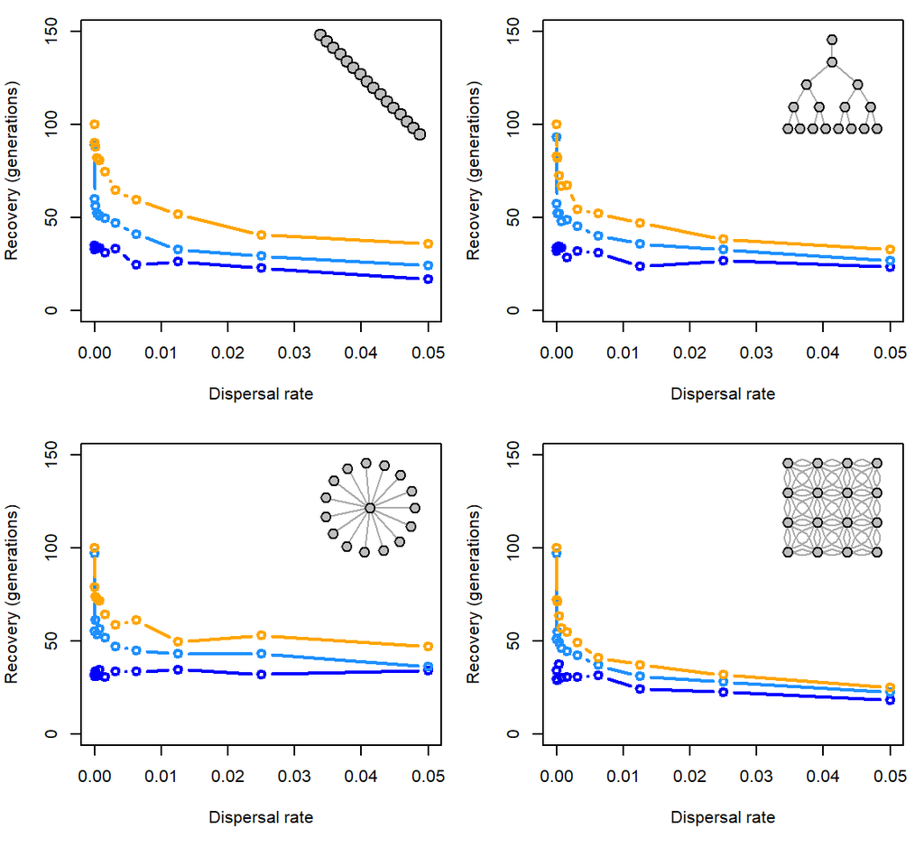

Recovery rates along dispersal, disturbance (blue - uniform; light blue - localized, random; orange - localized, extirpation), and network gradients with variable local productivity and carrying capacities.

Now, lets show recovery rates for the same scenario but allowing for recruitment to be stochastic (but patches are the same in demography). We see the same three main effects of dispersal, network, and disturbance noted above. We also see a few subtle changes: (1) stochasticity slows recovery for uniform and local disturbance, but (2) quickens recovery for extreme local disturbance.

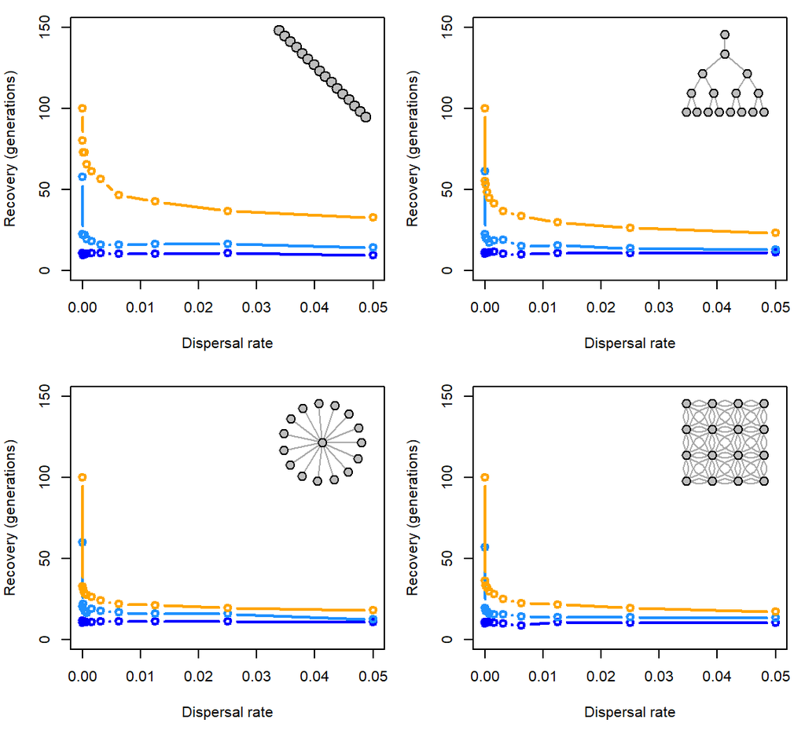

Recovery rates along dispersal, disturbance (blue - uniform; light blue - localized, random; orange - localized, extirpation), and network gradients with stochasticity.

Now, lets show recovery rates for the same scenarios but with spatial and temporal correlations in recruitment stochasticity. In addition to the same effects of stochasticity, we also generally see a small effect of slower recovery times for uniform and local disturbance, but faster recovery times for extreme localized disturbance.

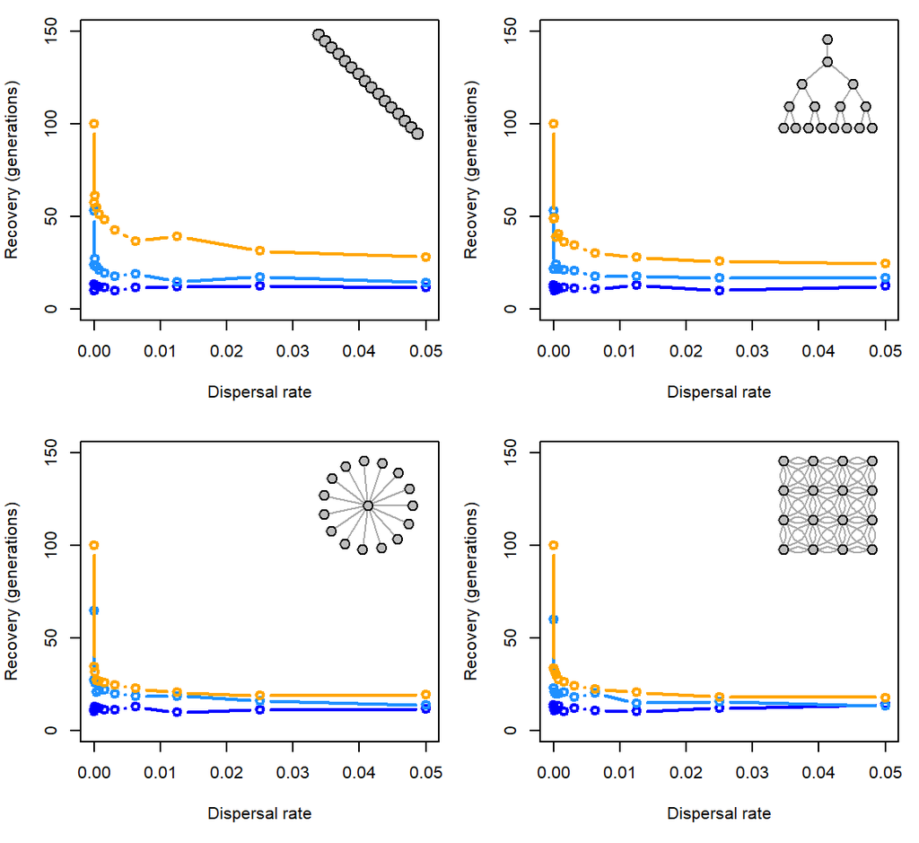

Recovery rates along dispersal, disturbance (blue - uniform; light blue - localized, random; orange - localized, extirpation), and network gradients with high spatial-temporal correlation in recruitment variation.

#### General patterns in MSY

##### MSY with deterministic recruitment where patches are the same

We now show similar patterns in how the maximum surplus production of the whole metapopulation (i.e., MSY) shifts in the first 10 years post-disturbance compared to the sum of MSY for each patch. A value of 1.0 would indicate that the disturbed metapopulation can sustain itselfs against the same disturbance regime as the sum of each patch independently. In other words, is the metapopulation more, less, or equal to the sum of its parts.

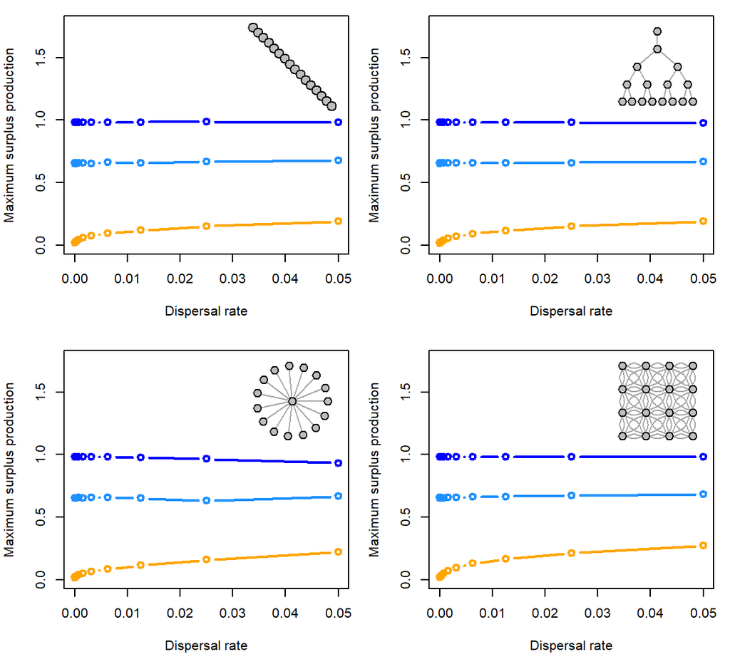

Maximum surplus production along dispersal, disturbance (blue - uniform; light blue - localized, random; orange - localized, extirpation), and network gradients with deterministic recruitment and the same patches.

##### MSY with variable patches

Now, we illustrate how variable patch demography affects the 10-year average MSY.

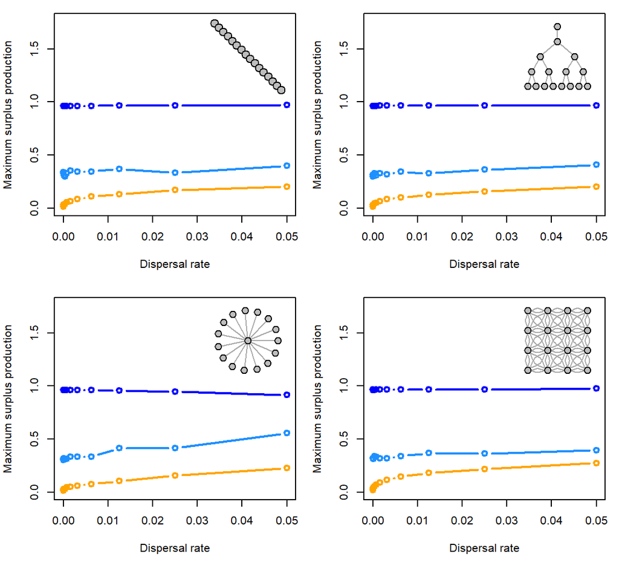

Maximum surplus production along dispersal, disturbance (blue - uniform; light blue - localized, random; orange - localized, extirpation), and network gradients with variable patches.

##### MSY with variable patches and stochasticity

Now, we illustrate how variable patch demography affects the 10-year average MSY.

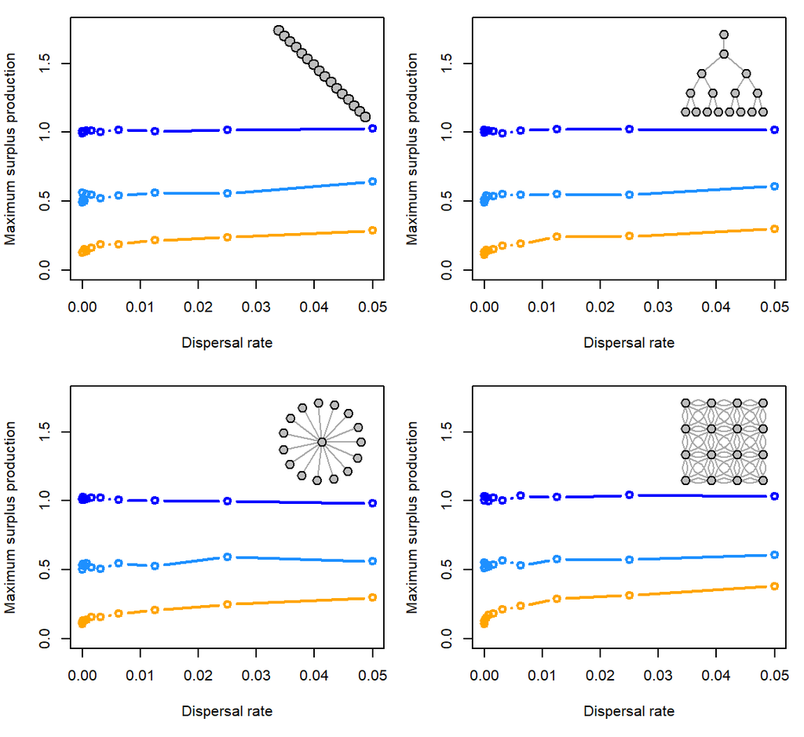

Maximum surplus production along dispersal, disturbance (blue - uniform; light blue - localized, random; orange - localized, extirpation), and network gradients with variable patches and stochasticity.

##### MSY with variable patches, and spatio-temporally correlated stochasticity

Now, we illustrate how variable patch demography and high spatial-temporal correlations in stochastic recruitment affects the 10-year average MSY.

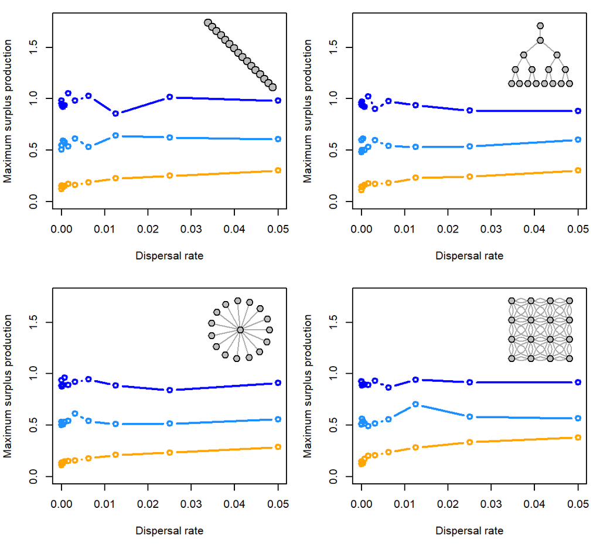

Maximum surplus production along dispersal, disturbance (blue - uniform; light blue - localized, random; orange - localized, extirpation), and network gradients with high spatial-temporal correlation in recruitment stochasticity and variable patches.

#### General patterns in the risk of hysteresis & state shifts

##### Proportion of simulations where the metapopulation either failed to recover or experienced spatial contraction for scenario with deterministic recruitment where patches are the same

We now show similar patterns in the lack of recovery across the metapopulation after $100$ generations post-disturbance.

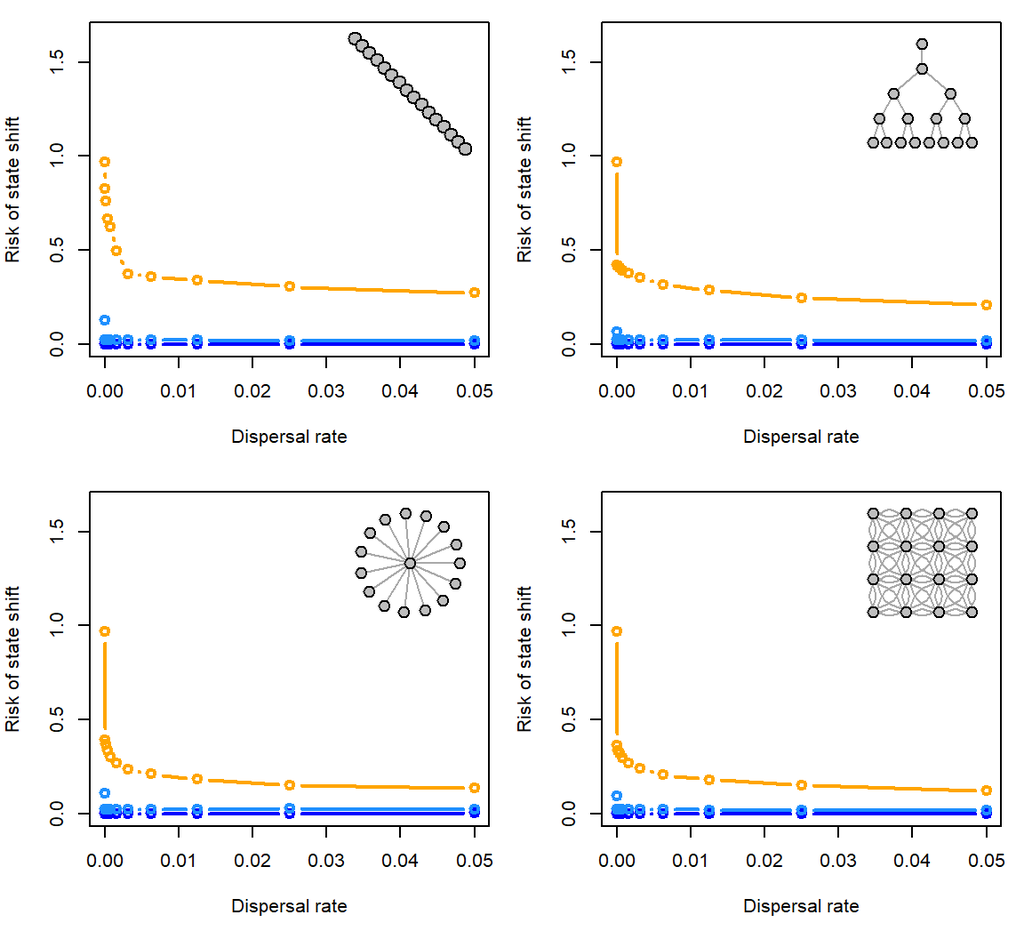

##### Lack of recovery with variable patches

Now, we illustrate how variable patch demography affects the risk of state shift.

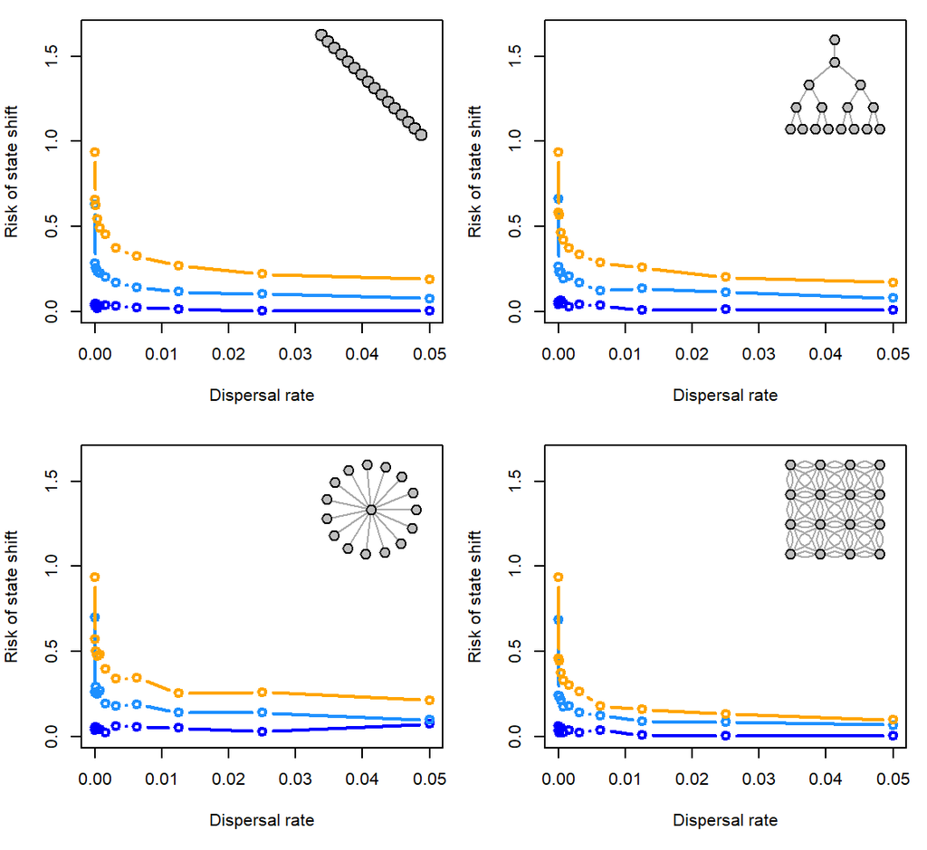

Risk of state shift after 100 generations along dispersal, disturbance (blue - uniform; light blue - localized, random; orange - localized, extirpation), and network gradients with variable patches.

##### State shifts with variable patches and stochasticity

Now, we illustrate how variable patch demography and stochastic recruitment affects the risk of state shift.

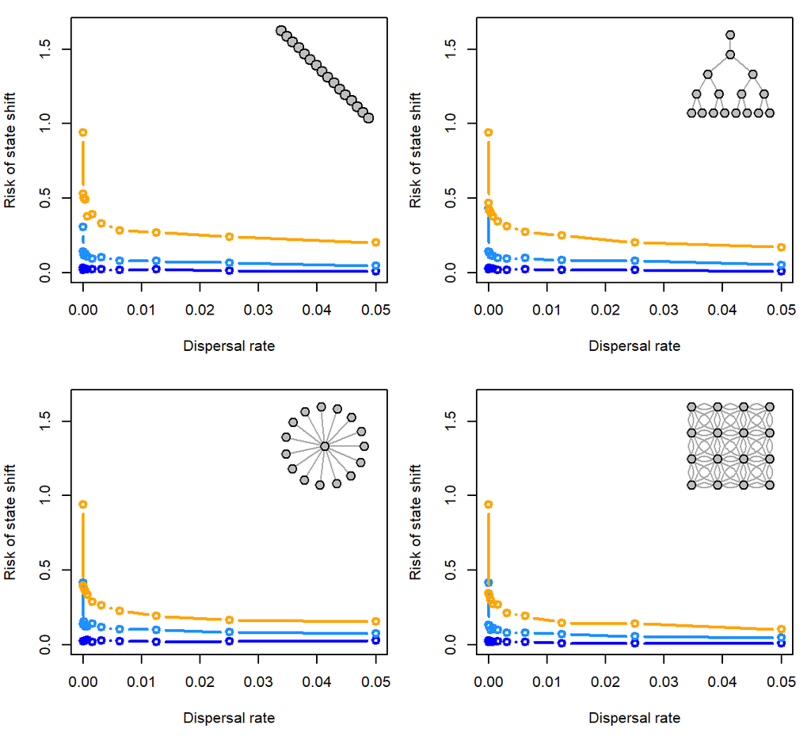

Risk of state shift after 100 generations along dispersal, disturbance (blue - uniform; light blue - localized, random; orange - localized, extirpation), and network gradients with variable patches and stochastic recruitment.

##### State shifts with variable patches, and spatio-temporally correlated stochasticity

Now, we illustrate how variable patch demography and high spatial-temporal correlations in stochastic recrtuitment affects the risk of a state shift.

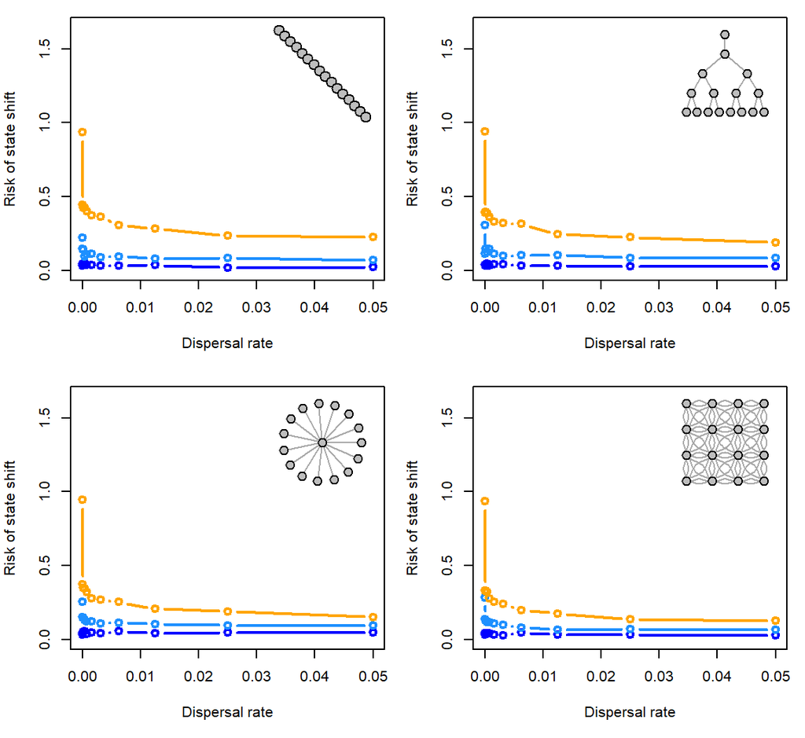

Risk of state shift (lack of recovery or spatial contraction) after 100 generations along dispersal, disturbance (blue - uniform; light blue - localized, random; orange - localized, extirpation), and network gradients with variable patches, and spatial-temporal correlations in stochastic recruitment.